# Ford GoBike System Dateset

## by Ganesh Rao

Ford GoBike System Dateset is a dateset that contains trip data from lyft's bike service for public use. Variables including, trip duration, start time and end time with date, start station and end station names, start and end coordinates, customer type, year of birth and gender

# Gathering data

#### Import library

```python
import pandas as pd
import numpy as np
import matplotlib.pyplot as plt
import seaborn as sns
from requests import get
from zipfile import ZipFile
from io import StringIO, BytesIO
%matplotlib inline
```

#### downloading main csv

```python
csv = get('https://s3.amazonaws.com/baywheels-data/2017-fordgobike-tripdata.csv')
csv
```

```
<Response [200]>
```

if the response is 200 that means the file is donwload and is in memory

```python
df = pd.read_csv(StringIO(csv.content.decode('utf-8')))
df.head()
```

|  | duration_sec | start_time | end_time | start_station_id | start_station_name | start_station_latitude | start_station_longitude | end_station_id | end_station_name | end_station_latitude | end_station_longitude | bike_id | user_type | member_birth_year | member_gender |
| --- | --- | --- | --- | --- | --- | --- | --- | --- | --- | --- | --- | --- | --- | --- | --- |
| 0 | 80110 | 2017-12-31 16:57:39.6540 | 2018-01-01 15:12:50.2450 | 74 | Laguna St at Hayes St | 37.776435 | -122.426244 | 43 | San Francisco Public Library (Grove St at Hyde... | 37.778768 | -122.415929 | 96 | Customer | 1987.0 | Male |
| 1 | 78800 | 2017-12-31 15:56:34.8420 | 2018-01-01 13:49:55.6170 | 284 | Yerba Buena Center for the Arts (Howard St at ... | 37.784872 | -122.400876 | 96 | Dolores St at 15th St | 37.766210 | -122.426614 | 88 | Customer | 1965.0 | Female |
| 2 | 45768 | 2017-12-31 22:45:48.4110 | 2018-01-01 11:28:36.8830 | 245 | Downtown Berkeley BART | 37.870348 | -122.267764 | 245 | Downtown Berkeley BART | 37.870348 | -122.267764 | 1094 | Customer | NaN | NaN |
| 3 | 62172 | 2017-12-31 17:31:10.6360 | 2018-01-01 10:47:23.5310 | 60 | 8th St at Ringold St | 37.774520 | -122.409449 | 5 | Powell St BART Station (Market St at 5th St) | 37.783899 | -122.408445 | 2831 | Customer | NaN | NaN |
| 4 | 43603 | 2017-12-31 14:23:14.0010 | 2018-01-01 02:29:57.5710 | 239 | Bancroft Way at Telegraph Ave | 37.868813 | -122.258764 | 247 | Fulton St at Bancroft Way | 37.867789 | -122.265896 | 3167 | Subscriber | 1997.0 | Female |

```python
df.shape
```

```
(519700, 15)
```

```python
df.info()
```

```
<class 'pandas.core.frame.DataFrame'>
RangeIndex: 519700 entries, 0 to 519699
Data columns (total 15 columns):
duration_sec               519700 non-null int64
start_time                 519700 non-null object
end_time                   519700 non-null object
start_station_id           519700 non-null int64
start_station_name         519700 non-null object
start_station_latitude     519700 non-null float64
start_station_longitude    519700 non-null float64
end_station_id             519700 non-null int64
end_station_name           519700 non-null object
end_station_latitude       519700 non-null float64
end_station_longitude      519700 non-null float64
bike_id                    519700 non-null int64
user_type                  519700 non-null object
member_birth_year          453159 non-null float64
member_gender              453238 non-null object
dtypes: float64(5), int64(4), object(6)
memory usage: 59.5+ MB
```

```python
df.isna().sum()
```

```
duration_sec                   0
start_time                     0
end_time                       0
start_station_id               0
start_station_name             0
start_station_latitude         0
start_station_longitude        0
end_station_id                 0
end_station_name               0
end_station_latitude           0
end_station_longitude          0
bike_id                        0
user_type                      0
member_birth_year          66541
member_gender              66462
dtype: int64
```

```python
df.user_type.value_counts()
```

```
Subscriber    409230
Customer      110470
Name: user_type, dtype: int64
```

```python
df.member_gender.value_counts()
```

```
Male      348318
Female     98621
Other       6299
Name: member_gender, dtype: int64
```

#### downloading zip files

```python
links = ["https://s3.amazonaws.com/baywheels-data/201801-fordgobike-tripdata.csv.zip","https://s3.amazonaws.com/baywheels-data/201802-fordgobike-tripdata.csv.zip"
        ,"https://s3.amazonaws.com/baywheels-data/201803-fordgobike-tripdata.csv.zip","https://s3.amazonaws.com/baywheels-data/201804-fordgobike-tripdata.csv.zip"
        ,"https://s3.amazonaws.com/baywheels-data/201805-fordgobike-tripdata.csv.zip","https://s3.amazonaws.com/baywheels-data/201806-fordgobike-tripdata.csv.zip"
        ,"https://s3.amazonaws.com/baywheels-data/201807-fordgobike-tripdata.csv.zip","https://s3.amazonaws.com/baywheels-data/201808-fordgobike-tripdata.csv.zip"
        ,"https://s3.amazonaws.com/baywheels-data/201809-fordgobike-tripdata.csv.zip","https://s3.amazonaws.com/baywheels-data/201810-fordgobike-tripdata.csv.zip"
        ,"https://s3.amazonaws.com/baywheels-data/201811-fordgobike-tripdata.csv.zip","https://s3.amazonaws.com/baywheels-data/201812-fordgobike-tripdata.csv.zip"
        ,"https://s3.amazonaws.com/baywheels-data/201901-fordgobike-tripdata.csv.zip","https://s3.amazonaws.com/baywheels-data/201902-fordgobike-tripdata.csv.zip"
        ,"https://s3.amazonaws.com/baywheels-data/201903-fordgobike-tripdata.csv.zip","https://s3.amazonaws.com/baywheels-data/201904-fordgobike-tripdata.csv.zip"
        ,"https://s3.amazonaws.com/baywheels-data/201905-baywheels-tripdata.csv.zip"]

for link in links:
    zipfile = get(link)
    with ZipFile(BytesIO(zipfile.content)) as file:
        file.extractall()
```

#### reading csvs

```python
paths = ['201802-fordgobike-tripdata.csv','201803-fordgobike-tripdata.csv'
        ,'201804-fordgobike-tripdata.csv','201805-fordgobike-tripdata.csv'
        ,'201806-fordgobike-tripdata.csv','201807-fordgobike-tripdata.csv'
        ,'201808-fordgobike-tripdata.csv','201809-fordgobike-tripdata.csv'
        ,'201810-fordgobike-tripdata.csv','201811-fordgobike-tripdata.csv'
        ,'201812-fordgobike-tripdata.csv','201901-fordgobike-tripdata.csv'
        ,'201902-fordgobike-tripdata.csv','201903-fordgobike-tripdata.csv'
        ,'201904-fordgobike-tripdata.csv','201905-baywheels-tripdata.csv']

df_extra = pd.read_csv('201801-fordgobike-tripdata.csv')
for path in paths:
    df_extra = df_extra.append(pd.read_csv(path))
```

```python
df_extra.head()
```

|  | duration_sec | start_time | end_time | start_station_id | start_station_name | start_station_latitude | start_station_longitude | end_station_id | end_station_name | end_station_latitude | end_station_longitude | bike_id | user_type | member_birth_year | member_gender | bike_share_for_all_trip |
| --- | --- | --- | --- | --- | --- | --- | --- | --- | --- | --- | --- | --- | --- | --- | --- | --- |
| 0 | 75284 | 2018-01-31 22:52:35.2390 | 2018-02-01 19:47:19.8240 | 120.0 | Mission Dolores Park | 37.761420 | -122.426435 | 285.0 | Webster St at O'Farrell St | 37.783521 | -122.431158 | 2765 | Subscriber | 1986.0 | Male | No |
| 1 | 85422 | 2018-01-31 16:13:34.3510 | 2018-02-01 15:57:17.3100 | 15.0 | San Francisco Ferry Building (Harry Bridges Pl... | 37.795392 | -122.394203 | 15.0 | San Francisco Ferry Building (Harry Bridges Pl... | 37.795392 | -122.394203 | 2815 | Customer | NaN | NaN | No |
| 2 | 71576 | 2018-01-31 14:23:55.8890 | 2018-02-01 10:16:52.1160 | 304.0 | Jackson St at 5th St | 37.348759 | -121.894798 | 296.0 | 5th St at Virginia St | 37.325998 | -121.877120 | 3039 | Customer | 1996.0 | Male | No |
| 3 | 61076 | 2018-01-31 14:53:23.5620 | 2018-02-01 07:51:20.5000 | 75.0 | Market St at Franklin St | 37.773793 | -122.421239 | 47.0 | 4th St at Harrison St | 37.780955 | -122.399749 | 321 | Customer | NaN | NaN | No |
| 4 | 39966 | 2018-01-31 19:52:24.6670 | 2018-02-01 06:58:31.0530 | 74.0 | Laguna St at Hayes St | 37.776435 | -122.426244 | 19.0 | Post St at Kearny St | 37.788975 | -122.403452 | 617 | Subscriber | 1991.0 | Male | No |

```python
df_extra.shape
```

```
(2916788, 16)
```

```python
df_extra.info()
```

```
<class 'pandas.core.frame.DataFrame'>
Int64Index: 2916788 entries, 0 to 182162
Data columns (total 16 columns):
duration_sec               int64
start_time                 object
end_time                   object
start_station_id           float64
start_station_name         object
start_station_latitude     float64
start_station_longitude    float64
end_station_id             float64
end_station_name           object
end_station_latitude       float64
end_station_longitude      float64
bike_id                    int64
user_type                  object
member_birth_year          float64
member_gender              object
bike_share_for_all_trip    object
dtypes: float64(7), int64(2), object(7)
memory usage: 378.3+ MB
```

#### droped "bike_share_for_all_trip" becuse it was not in the documentation

```python
df_extra.drop(['bike_share_for_all_trip'],inplace=True,axis=1)
```

```python
df_extra.info()
```

```
<class 'pandas.core.frame.DataFrame'>
Int64Index: 2916788 entries, 0 to 182162
Data columns (total 15 columns):
duration_sec               int64
start_time                 object
end_time                   object
start_station_id           float64
start_station_name         object
start_station_latitude     float64
start_station_longitude    float64
end_station_id             float64
end_station_name           object
end_station_latitude       float64
end_station_longitude      float64
bike_id                    int64
user_type                  object
member_birth_year          float64
member_gender              object
dtypes: float64(7), int64(2), object(6)
memory usage: 356.1+ MB
```

```python
df_extra.isna().sum()
```

```
duration_sec                    0
start_time                      0
end_time                        0
start_station_id            12516
start_station_name          12516
start_station_latitude          0
start_station_longitude         0
end_station_id              12516
end_station_name            12516
end_station_latitude            0
end_station_longitude           0
bike_id                         0
user_type                       0
member_birth_year          160094
member_gender              159737
dtype: int64
```

# Cleaning data

```python
df_clean = df.copy()
df_extra_clean = df_extra.copy()
```

### df_clean

#### DEFINE: start_station_id, end_station_id and bike_id to strings

#### Code:

```python
def change_to_string(df,fields):
    for field in fields:
        df[field] = df[field].astype(np.object)
    return df
```

```python
df_clean = change_to_string (df_clean,['start_station_id', 'end_station_id','bike_id'])
```

#### Test:

```python
df_clean.info()
```

```
<class 'pandas.core.frame.DataFrame'>
RangeIndex: 519700 entries, 0 to 519699
Data columns (total 15 columns):
duration_sec               519700 non-null int64
start_time                 519700 non-null object
end_time                   519700 non-null object
start_station_id           519700 non-null object
start_station_name         519700 non-null object
start_station_latitude     519700 non-null float64
start_station_longitude    519700 non-null float64
end_station_id             519700 non-null object
end_station_name           519700 non-null object
end_station_latitude       519700 non-null float64
end_station_longitude      519700 non-null float64
bike_id                    519700 non-null object
user_type                  519700 non-null object
member_birth_year          453159 non-null float64
member_gender              453238 non-null object
dtypes: float64(5), int64(1), object(9)
memory usage: 59.5+ MB
```

#### DEFINE: change start_time and end_time to timestamp

#### Code:

```python
df_clean['start_time'] = df_clean['start_time'].astype('datetime64[ns]')
df_clean['end_time'] = df_clean['end_time'].astype('datetime64[ns]')
```

#### Test:

```python
df_clean.info()
```

```
<class 'pandas.core.frame.DataFrame'>
RangeIndex: 519700 entries, 0 to 519699
Data columns (total 15 columns):
duration_sec               519700 non-null int64
start_time                 519700 non-null datetime64[ns]
end_time                   519700 non-null datetime64[ns]
start_station_id           519700 non-null object
start_station_name         519700 non-null object
start_station_latitude     519700 non-null float64
start_station_longitude    519700 non-null float64
end_station_id             519700 non-null object
end_station_name           519700 non-null object
end_station_latitude       519700 non-null float64
end_station_longitude      519700 non-null float64
bike_id                    519700 non-null object
user_type                  519700 non-null object
member_birth_year          453159 non-null float64
member_gender              453238 non-null object
dtypes: datetime64[ns](2), float64(5), int64(1), object(7)
memory usage: 59.5+ MB
```

#### DEFINE: user_type and member_gender should be categorical

#### code:

```python
def change_to_category(df,fields):
    for field in fields:
        df[field] = df[field].astype('category')
    return df
```

```python
df_clean = change_to_category (df_clean,['user_type', 'member_gender'])
```

#### Test:

```python
df_clean.info()
```

```
<class 'pandas.core.frame.DataFrame'>
RangeIndex: 519700 entries, 0 to 519699
Data columns (total 15 columns):
duration_sec               519700 non-null int64
start_time                 519700 non-null datetime64[ns]
end_time                   519700 non-null datetime64[ns]
start_station_id           519700 non-null object
start_station_name         519700 non-null object
start_station_latitude     519700 non-null float64
start_station_longitude    519700 non-null float64
end_station_id             519700 non-null object
end_station_name           519700 non-null object
end_station_latitude       519700 non-null float64
end_station_longitude      519700 non-null float64
bike_id                    519700 non-null object
user_type                  519700 non-null category
member_birth_year          453159 non-null float64
member_gender              453238 non-null category
dtypes: category(2), datetime64[ns](2), float64(5), int64(1), object(5)
memory usage: 52.5+ MB
```

### df_extra_clean

#### DEFINE: start_station_id, end_station_id and bike_id to strings

#### Code:

```python
df_extra_clean = change_to_string (df_extra_clean,['start_station_id', 'end_station_id','bike_id'])
```

#### Test:

```python
df_extra_clean.info()
```

```
<class 'pandas.core.frame.DataFrame'>
Int64Index: 2916788 entries, 0 to 182162
Data columns (total 15 columns):
duration_sec               int64
start_time                 object
end_time                   object
start_station_id           object
start_station_name         object
start_station_latitude     float64
start_station_longitude    float64
end_station_id             object
end_station_name           object
end_station_latitude       float64
end_station_longitude      float64
bike_id                    object
user_type                  object
member_birth_year          float64
member_gender              object
dtypes: float64(5), int64(1), object(9)
memory usage: 356.1+ MB
```

#### DEFINE: change start_time and end_time to timestamp

#### Code:

```python
df_extra_clean['start_time'] = df_extra_clean['start_time'].astype('datetime64[ns]')
df_extra_clean['end_time'] = df_extra_clean['end_time'].astype('datetime64[ns]')
```

#### Test:

```python
df_extra_clean.info()
```

```
<class 'pandas.core.frame.DataFrame'>
Int64Index: 2916788 entries, 0 to 182162
Data columns (total 15 columns):
duration_sec               int64
start_time                 datetime64[ns]
end_time                   datetime64[ns]
start_station_id           object
start_station_name         object
start_station_latitude     float64
start_station_longitude    float64
end_station_id             object
end_station_name           object
end_station_latitude       float64
end_station_longitude      float64
bike_id                    object
user_type                  object
member_birth_year          float64
member_gender              object
dtypes: datetime64[ns](2), float64(5), int64(1), object(7)
memory usage: 356.1+ MB
```

#### DEFINE: user_type and member_gender should be categorical

#### Code:

```python
df_extra_clean = change_to_category (df_extra_clean,['user_type', 'member_gender'])
```

#### Test:

```python
df_extra_clean.info()
```

```
<class 'pandas.core.frame.DataFrame'>
Int64Index: 2916788 entries, 0 to 182162
Data columns (total 15 columns):
duration_sec               int64
start_time                 datetime64[ns]
end_time                   datetime64[ns]
start_station_id           object
start_station_name         object
start_station_latitude     float64
start_station_longitude    float64
end_station_id             object
end_station_name           object
end_station_latitude       float64
end_station_longitude      float64
bike_id                    object
user_type                  category
member_birth_year          float64
member_gender              category
dtypes: category(2), datetime64[ns](2), float64(5), int64(1), object(5)
memory usage: 317.1+ MB
```

#### DEFINE: drop the rows with nulls start_station_id, start_station_name, end_station_id or end_station_name.

#### Code:

```python
df_extra_clean[df_extra_clean['start_station_id'].isnull()]
```

|  | duration_sec | start_time | end_time | start_station_id | start_station_name | start_station_latitude | start_station_longitude | end_station_id | end_station_name | end_station_latitude | end_station_longitude | bike_id | user_type | member_birth_year | member_gender |
| --- | --- | --- | --- | --- | --- | --- | --- | --- | --- | --- | --- | --- | --- | --- | --- |
| 168 | 5572 | 2018-06-30 20:58:31.855 | 2018-06-30 22:31:24.593 | NaN | NaN | 37.40 | -121.94 | NaN | NaN | 37.40 | -121.94 | 4202 | Customer | 1989.0 | Male |
| 180 | 573 | 2018-06-30 22:12:27.511 | 2018-06-30 22:22:01.174 | NaN | NaN | 37.40 | -121.94 | NaN | NaN | 37.40 | -121.93 | 4095 | Subscriber | 1994.0 | Male |
| 197 | 850 | 2018-06-30 22:01:25.585 | 2018-06-30 22:15:36.151 | NaN | NaN | 37.41 | -121.94 | NaN | NaN | 37.41 | -121.95 | 4122 | Customer | 1990.0 | Male |
| 233 | 562 | 2018-06-30 21:52:05.118 | 2018-06-30 22:01:27.440 | NaN | NaN | 37.41 | -121.94 | NaN | NaN | 37.42 | -121.94 | 4184 | Subscriber | 1989.0 | Male |
| 260 | 819 | 2018-06-30 21:37:34.506 | 2018-06-30 21:51:13.729 | NaN | NaN | 37.41 | -121.94 | NaN | NaN | 37.41 | -121.96 | 4137 | Customer | 1985.0 | Male |
| 276 | 1176 | 2018-06-30 21:23:30.488 | 2018-06-30 21:43:07.331 | NaN | NaN | 37.41 | -121.94 | NaN | NaN | 37.41 | -121.94 | 4152 | Customer | 1961.0 | Male |
| 283 | 160 | 2018-06-30 21:37:50.926 | 2018-06-30 21:40:30.930 | NaN | NaN | 37.41 | -121.94 | NaN | NaN | 37.42 | -121.94 | 4105 | Subscriber | 1990.0 | Female |
| 352 | 7242 | 2018-06-30 19:19:19.560 | 2018-06-30 21:20:02.111 | NaN | NaN | 37.40 | -121.94 | NaN | NaN | 37.40 | -121.94 | 4082 | Customer | 1990.0 | Male |
| 353 | 725 | 2018-06-30 21:06:44.358 | 2018-06-30 21:18:50.218 | NaN | NaN | 37.41 | -121.96 | NaN | NaN | 37.41 | -121.96 | 4156 | Customer | 1983.0 | Male |
| 354 | 694 | 2018-06-30 21:05:49.618 | 2018-06-30 21:17:24.267 | NaN | NaN | 37.40 | -121.93 | NaN | NaN | 37.41 | -121.94 | 4136 | Customer | 1987.0 | Female |
| 355 | 1608 | 2018-06-30 20:50:23.745 | 2018-06-30 21:17:12.639 | NaN | NaN | 37.40 | -121.92 | NaN | NaN | 37.41 | -121.94 | 4184 | Customer | 1986.0 | Male |
| 367 | 1444 | 2018-06-30 20:49:04.198 | 2018-06-30 21:13:08.898 | NaN | NaN | 37.40 | -121.94 | NaN | NaN | 37.40 | -121.94 | 4135 | Customer | 1982.0 | Male |
| 377 | 3855 | 2018-06-30 20:06:14.458 | 2018-06-30 21:10:29.552 | NaN | NaN | 37.40 | -121.93 | NaN | NaN | 37.40 | -121.93 | 4171 | Customer | 1975.0 | Male |
| 385 | 3344 | 2018-06-30 20:12:39.047 | 2018-06-30 21:08:23.112 | NaN | NaN | 37.40 | -121.94 | NaN | NaN | 37.40 | -121.94 | 4110 | Customer | 1988.0 | Female |
| 404 | 1700 | 2018-06-30 20:30:05.176 | 2018-06-30 20:58:25.796 | NaN | NaN | 37.40 | -121.94 | NaN | NaN | 37.40 | -121.94 | 4202 | Subscriber | 1984.0 | Male |
| 467 | 462 | 2018-06-30 20:31:55.157 | 2018-06-30 20:39:38.037 | NaN | NaN | 37.41 | -121.93 | NaN | NaN | 37.40 | -121.92 | 4132 | Subscriber | NaN | NaN |
| 474 | 1320 | 2018-06-30 20:13:48.802 | 2018-06-30 20:35:49.622 | NaN | NaN | 37.40 | -121.92 | NaN | NaN | 37.40 | -121.92 | 4237 | Subscriber | 1988.0 | Male |
| 500 | 3780 | 2018-06-30 19:25:16.000 | 2018-06-30 20:28:16.073 | NaN | NaN | 37.40 | -121.94 | NaN | NaN | 37.40 | -121.94 | 4202 | Customer | 1987.0 | Female |
| 502 | 328 | 2018-06-30 20:22:16.230 | 2018-06-30 20:27:44.272 | NaN | NaN | 37.41 | -121.94 | NaN | NaN | 37.41 | -121.94 | 4092 | Subscriber | 1989.0 | Male |
| 521 | 1737 | 2018-06-30 19:55:39.731 | 2018-06-30 20:24:36.788 | NaN | NaN | 37.40 | -121.94 | NaN | NaN | 37.41 | -121.94 | 4152 | Customer | 1994.0 | Female |
| 522 | 1626 | 2018-06-30 19:57:28.953 | 2018-06-30 20:24:35.463 | NaN | NaN | 37.40 | -121.94 | NaN | NaN | 37.41 | -121.94 | 4122 | Customer | 1994.0 | Female |
| 555 | 459 | 2018-06-30 20:06:35.738 | 2018-06-30 20:14:15.308 | NaN | NaN | 37.42 | -121.96 | NaN | NaN | 37.41 | -121.96 | 4251 | Subscriber | 1992.0 | Other |
| 557 | 1613 | 2018-06-30 19:47:02.090 | 2018-06-30 20:13:55.771 | NaN | NaN | 37.41 | -121.94 | NaN | NaN | 37.41 | -121.94 | 4092 | Customer | 1987.0 | Male |
| 604 | 1565 | 2018-06-30 19:34:00.397 | 2018-06-30 20:00:06.027 | NaN | NaN | 37.40 | -121.93 | NaN | NaN | 37.41 | -121.94 | 4137 | Customer | 1988.0 | Male |
| 614 | 1768 | 2018-06-30 19:28:06.804 | 2018-06-30 19:57:35.022 | NaN | NaN | 37.40 | -121.94 | NaN | NaN | 37.40 | -121.94 | 4098 | Customer | 1976.0 | Male |
| 671 | 2003 | 2018-06-30 19:09:00.711 | 2018-06-30 19:42:24.686 | NaN | NaN | 37.40 | -121.94 | NaN | NaN | 37.41 | -121.94 | 4089 | Customer | 1991.0 | Male |
| 674 | 1878 | 2018-06-30 19:10:56.988 | 2018-06-30 19:42:15.409 | NaN | NaN | 37.40 | -121.94 | NaN | NaN | 37.41 | -121.94 | 4092 | Customer | 1989.0 | Male |
| 679 | 1655 | 2018-06-30 19:13:57.516 | 2018-06-30 19:41:33.248 | NaN | NaN | 37.40 | -121.94 | NaN | NaN | 37.40 | -121.94 | 4194 | Customer | 1986.0 | Male |
| 727 | 1828 | 2018-06-30 19:01:40.239 | 2018-06-30 19:32:08.296 | NaN | NaN | 37.41 | -121.94 | NaN | NaN | 37.40 | -121.93 | 4137 | Customer | 1988.0 | Male |
| 729 | 81932 | 2018-06-29 20:46:13.931 | 2018-06-30 19:31:46.439 | NaN | NaN | 37.40 | -121.94 | NaN | NaN | 37.40 | -121.94 | 4232 | Subscriber | 1992.0 | Male |
| ... | ... | ... | ... | ... | ... | ... | ... | ... | ... | ... | ... | ... | ... | ... | ... |
| 131384 | 633 | 2019-04-11 17:29:51.674 | 2019-04-11 17:40:25.075 | NaN | NaN | 37.39 | -121.93 | NaN | NaN | 37.40 | -121.93 | 4098 | Subscriber | 1983.0 | Male |
| 148369 | 432 | 2019-04-10 09:46:00.573 | 2019-04-10 09:53:12.958 | NaN | NaN | 37.40 | -121.94 | NaN | NaN | 37.39 | -121.93 | 4098 | Subscriber | 1986.0 | Male |
| 159974 | 601 | 2019-04-09 10:50:05.085 | 2019-04-09 11:00:06.574 | NaN | NaN | 37.41 | -121.95 | NaN | NaN | 37.41 | -121.95 | 4107 | Subscriber | 1992.0 | Male |
| 175807 | 108 | 2019-04-07 19:26:56.562 | 2019-04-07 19:28:44.991 | NaN | NaN | 37.40 | -121.94 | NaN | NaN | 37.40 | -121.94 | 4211 | Customer | 1987.0 | Female |
| 176448 | 1276 | 2019-04-07 17:56:20.550 | 2019-04-07 18:17:36.628 | NaN | NaN | 37.40 | -121.93 | NaN | NaN | 37.40 | -121.94 | 4211 | Subscriber | 1988.0 | Male |
| 200310 | 1041 | 2019-04-04 18:33:16.831 | 2019-04-04 18:50:37.871 | NaN | NaN | 37.36 | -121.89 | NaN | NaN | 37.36 | -121.89 | 4093 | Customer | 2001.0 | Male |
| 221529 | 1342 | 2019-04-02 19:08:43.691 | 2019-04-02 19:31:06.626 | NaN | NaN | 37.40 | -121.93 | NaN | NaN | 37.40 | -121.92 | 4211 | Customer | 1989.0 | Male |
| 222061 | 1132 | 2019-04-02 18:30:33.032 | 2019-04-02 18:49:25.434 | NaN | NaN | 37.41 | -121.93 | NaN | NaN | 37.41 | -121.94 | 4085 | Customer | 1994.0 | Male |
| 222458 | 1241 | 2019-04-02 18:05:53.093 | 2019-04-02 18:26:34.363 | NaN | NaN | 37.41 | -121.95 | NaN | NaN | 37.41 | -121.95 | 4107 | Customer | 1994.0 | Male |
| 224405 | 1403 | 2019-04-02 16:33:41.332 | 2019-04-02 16:57:04.470 | NaN | NaN | 37.40 | -121.93 | NaN | NaN | 37.36 | -121.89 | 4093 | Customer | 1962.0 | Male |
| 226208 | 681 | 2019-04-02 12:27:15.531 | 2019-04-02 12:38:36.932 | NaN | NaN | 37.39 | -121.93 | NaN | NaN | 37.40 | -121.93 | 4211 | Subscriber | 1986.0 | Male |
| 230020 | 4803 | 2019-04-01 19:03:07.473 | 2019-04-01 20:23:10.731 | NaN | NaN | 37.40 | -121.93 | NaN | NaN | 37.40 | -121.94 | 4270 | Customer | 1995.0 | Male |
| 232901 | 13460 | 2019-04-01 13:42:15.073 | 2019-04-01 17:26:35.895 | NaN | NaN | 37.41 | -121.95 | NaN | NaN | 37.40 | -121.94 | 4098 | Customer | 1991.0 | Male |
| 234606 | 229 | 2019-04-01 13:17:14.567 | 2019-04-01 13:21:03.941 | NaN | NaN | 37.41 | -121.94 | NaN | NaN | 37.41 | -121.94 | 4098 | Customer | 1991.0 | Male |
| 238139 | 647 | 2019-04-01 07:50:49.536 | 2019-04-01 08:01:37.242 | NaN | NaN | 37.40 | -121.93 | NaN | NaN | 37.39 | -121.93 | 4211 | Subscriber | 1983.0 | Male |
| 29190 | 846 | 2019-05-27 19:25:04.361 | 2019-05-27 19:39:10.557 | NaN | NaN | 37.41 | -121.94 | NaN | NaN | 37.40 | -121.92 | 4284 | Subscriber | 1995.0 | Male |
| 29279 | 1058 | 2019-05-27 18:53:49.380 | 2019-05-27 19:11:27.560 | NaN | NaN | 37.40 | -121.92 | NaN | NaN | 37.41 | -121.94 | 4284 | Subscriber | 1995.0 | Male |
| 30005 | 850 | 2019-05-27 16:10:58.164 | 2019-05-27 16:25:08.166 | NaN | NaN | 37.42 | -121.95 | NaN | NaN | 37.40 | -121.92 | 4284 | Customer | 1994.0 | Male |
| 30134 | 969 | 2019-05-27 15:41:27.262 | 2019-05-27 15:57:36.263 | NaN | NaN | 37.40 | -121.93 | NaN | NaN | 37.42 | -121.96 | 4284 | Customer | 1994.0 | Male |
| 109679 | 537 | 2019-05-12 17:04:49.466 | 2019-05-12 17:13:46.675 | NaN | NaN | 37.39 | -121.93 | NaN | NaN | 37.39 | -121.93 | 4106 | Customer | 1983.0 | Other |
| 127853 | 1239 | 2019-05-09 09:50:01.986 | 2019-05-09 10:10:41.783 | NaN | NaN | 37.39 | -121.93 | NaN | NaN | 37.39 | -121.93 | 4106 | Customer | 1988.0 | Male |
| 128632 | 1927 | 2019-05-09 08:37:08.867 | 2019-05-09 09:09:16.578 | NaN | NaN | 37.41 | -121.96 | NaN | NaN | 37.39 | -121.93 | 4106 | Customer | 1988.0 | Male |
| 132261 | 1254 | 2019-05-08 17:57:55.080 | 2019-05-08 18:18:49.085 | NaN | NaN | 37.38 | -121.94 | NaN | NaN | 37.38 | -121.94 | 4162 | Customer | 2000.0 | Male |
| 137960 | 594 | 2019-05-08 04:06:11.069 | 2019-05-08 04:16:05.769 | NaN | NaN | 37.41 | -121.94 | NaN | NaN | 37.41 | -121.96 | 4106 | Subscriber | 1999.0 | Male |
| 138026 | 731 | 2019-05-07 23:55:11.866 | 2019-05-08 00:07:22.886 | NaN | NaN | 37.41 | -121.96 | NaN | NaN | 37.41 | -121.94 | 4106 | Subscriber | 1999.0 | Male |
| 139863 | 606 | 2019-05-07 18:02:01.076 | 2019-05-07 18:12:07.386 | NaN | NaN | 37.42 | -121.96 | NaN | NaN | 37.41 | -121.96 | 4106 | Subscriber | 1999.0 | Male |
| 140736 | 484 | 2019-05-07 17:10:26.571 | 2019-05-07 17:18:31.271 | NaN | NaN | 37.41 | -121.96 | NaN | NaN | 37.42 | -121.95 | 4106 | Subscriber | 1999.0 | Male |
| 157253 | 1296 | 2019-05-04 16:08:22.279 | 2019-05-04 16:29:59.081 | NaN | NaN | 37.40 | -121.94 | NaN | NaN | 37.41 | -121.96 | 4106 | Customer | 1994.0 | Male |
| 157907 | 841 | 2019-05-04 14:00:20.333 | 2019-05-04 14:14:22.288 | NaN | NaN | 37.42 | -121.96 | NaN | NaN | 37.40 | -121.94 | 4106 | Customer | 2000.0 | Female |
| 158019 | 507 | 2019-05-04 13:41:19.273 | 2019-05-04 13:49:46.471 | NaN | NaN | 37.42 | -121.96 | NaN | NaN | 37.42 | -121.96 | 4106 | Customer | 2000.0 | Female |

12516 rows × 15 columns

```python
df_extra_clean.drop(df_extra_clean[df_extra_clean['start_station_id'].isnull()].index, inplace = True)
```

#### Test:

```python
df_extra_clean[df_extra_clean['start_station_id'].isnull()]
```

|  | duration_sec | start_time | end_time | start_station_id | start_station_name | start_station_latitude | start_station_longitude | end_station_id | end_station_name | end_station_latitude | end_station_longitude | bike_id | user_type | member_birth_year | member_gender |
| --- | --- | --- | --- | --- | --- | --- | --- | --- | --- | --- | --- | --- | --- | --- | --- |

```python
df_extra_clean.isna().sum()
```

```
duration_sec                    0
start_time                      0
end_time                        0
start_station_id                0
start_station_name              0
start_station_latitude          0
start_station_longitude         0
end_station_id                  0
end_station_name                0
end_station_latitude            0
end_station_longitude           0
bike_id                         0
user_type                       0
member_birth_year          150503
member_gender              150162
dtype: int64
```

```python
df_extra_clean.info()
```

```
<class 'pandas.core.frame.DataFrame'>
Int64Index: 2738678 entries, 3 to 182162
Data columns (total 15 columns):
duration_sec               int64
start_time                 datetime64[ns]
end_time                   datetime64[ns]
start_station_id           object
start_station_name         object
start_station_latitude     float64
start_station_longitude    float64
end_station_id             object
end_station_name           object
end_station_latitude       float64
end_station_longitude      float64
bike_id                    object
user_type                  category
member_birth_year          float64
member_gender              category
dtypes: category(2), datetime64[ns](2), float64(5), int64(1), object(5)
memory usage: 297.7+ MB
```

### join all data into one csv

```python
df_clean.shape
```

```
(519700, 15)
```

```python
df_extra_clean.shape
```

```
(2738678, 15)
```

```python
df = df_clean.append(df_extra_clean)
```

```python
df.info()
```

```
<class 'pandas.core.frame.DataFrame'>
Int64Index: 3258378 entries, 0 to 182162
Data columns (total 15 columns):
duration_sec               int64
start_time                 datetime64[ns]
end_time                   datetime64[ns]
start_station_id           object
start_station_name         object
start_station_latitude     float64
start_station_longitude    float64
end_station_id             object
end_station_name           object
end_station_latitude       float64
end_station_longitude      float64
bike_id                    object
user_type                  category
member_birth_year          float64
member_gender              category
dtypes: category(2), datetime64[ns](2), float64(5), int64(1), object(5)
memory usage: 354.2+ MB
```

```python
df.reset_index(inplace=True)
```

```python
df.head()
```

|  | index | duration_sec | start_time | end_time | start_station_id | start_station_name | start_station_latitude | start_station_longitude | end_station_id | end_station_name | end_station_latitude | end_station_longitude | bike_id | user_type | member_birth_year | member_gender |
| --- | --- | --- | --- | --- | --- | --- | --- | --- | --- | --- | --- | --- | --- | --- | --- | --- |
| 0 | 0 | 80110 | 2017-12-31 16:57:39.654 | 2018-01-01 15:12:50.245 | 74 | Laguna St at Hayes St | 37.776435 | -122.426244 | 43 | San Francisco Public Library (Grove St at Hyde... | 37.778768 | -122.415929 | 96 | Customer | 1987.0 | Male |
| 1 | 1 | 78800 | 2017-12-31 15:56:34.842 | 2018-01-01 13:49:55.617 | 284 | Yerba Buena Center for the Arts (Howard St at ... | 37.784872 | -122.400876 | 96 | Dolores St at 15th St | 37.766210 | -122.426614 | 88 | Customer | 1965.0 | Female |
| 2 | 2 | 45768 | 2017-12-31 22:45:48.411 | 2018-01-01 11:28:36.883 | 245 | Downtown Berkeley BART | 37.870348 | -122.267764 | 245 | Downtown Berkeley BART | 37.870348 | -122.267764 | 1094 | Customer | NaN | NaN |
| 3 | 3 | 62172 | 2017-12-31 17:31:10.636 | 2018-01-01 10:47:23.531 | 60 | 8th St at Ringold St | 37.774520 | -122.409449 | 5 | Powell St BART Station (Market St at 5th St) | 37.783899 | -122.408445 | 2831 | Customer | NaN | NaN |
| 4 | 4 | 43603 | 2017-12-31 14:23:14.001 | 2018-01-01 02:29:57.571 | 239 | Bancroft Way at Telegraph Ave | 37.868813 | -122.258764 | 247 | Fulton St at Bancroft Way | 37.867789 | -122.265896 | 3167 | Subscriber | 1997.0 | Female |

```python
df.drop(['index'],axis=1,inplace=True)
```

```python
df.shape
```

```
(3258378, 15)
```

```python
df.to_csv("master_data_frame.csv", sep=',', encoding='utf-8')
```

### What is the structure of your dataset?

copied form [here](https://www.lyft.com/bikes/bay-wheels/system-data)

Each trip is anonymized and includes:

Trip Duration (seconds)

Start Time and Date

End Time and Date

Start Station ID

Start Station Name

Start Station Latitude

Start Station Longitude

End Station ID

End Station Name

End Station Latitude

End Station Longitude

Bike ID

User Type (Subscriber or Customer – “Subscriber” = Member or “Customer” = Casual)

Member Year of Birth

Member Gender

### What is/are the main feature(s) of interest in your dataset?

User Type

Member Gender

### What features in the dataset do you think will help support your investigation into your feature(s) of interest?

Trip Duration (seconds)

Start Station Latitude

Start Station Longitude

End Station Latitude

End Station Longitude

Member Year of Birth

# Univariate Exploration

```python
df = pd.read_csv("master_data_frame.csv",index_col=0)
```

```python
df.head()
```

|  | duration_sec | start_time | end_time | start_station_id | start_station_name | start_station_latitude | start_station_longitude | end_station_id | end_station_name | end_station_latitude | end_station_longitude | bike_id | user_type | member_birth_year | member_gender |
| --- | --- | --- | --- | --- | --- | --- | --- | --- | --- | --- | --- | --- | --- | --- | --- |
| 0 | 80110 | 2017-12-31 16:57:39.654 | 2018-01-01 15:12:50.245 | 74.0 | Laguna St at Hayes St | 37.776435 | -122.426244 | 43.0 | San Francisco Public Library (Grove St at Hyde... | 37.778768 | -122.415929 | 96 | Customer | 1987.0 | Male |
| 1 | 78800 | 2017-12-31 15:56:34.842 | 2018-01-01 13:49:55.617 | 284.0 | Yerba Buena Center for the Arts (Howard St at ... | 37.784872 | -122.400876 | 96.0 | Dolores St at 15th St | 37.766210 | -122.426614 | 88 | Customer | 1965.0 | Female |
| 2 | 45768 | 2017-12-31 22:45:48.411 | 2018-01-01 11:28:36.883 | 245.0 | Downtown Berkeley BART | 37.870348 | -122.267764 | 245.0 | Downtown Berkeley BART | 37.870348 | -122.267764 | 1094 | Customer | NaN | NaN |
| 3 | 62172 | 2017-12-31 17:31:10.636 | 2018-01-01 10:47:23.531 | 60.0 | 8th St at Ringold St | 37.774520 | -122.409449 | 5.0 | Powell St BART Station (Market St at 5th St) | 37.783899 | -122.408445 | 2831 | Customer | NaN | NaN |
| 4 | 43603 | 2017-12-31 14:23:14.001 | 2018-01-01 02:29:57.571 | 239.0 | Bancroft Way at Telegraph Ave | 37.868813 | -122.258764 | 247.0 | Fulton St at Bancroft Way | 37.867789 | -122.265896 | 3167 | Subscriber | 1997.0 | Female |

```python
df.info()
```

```
<class 'pandas.core.frame.DataFrame'>
Int64Index: 3258378 entries, 0 to 3258377
Data columns (total 15 columns):
duration_sec               int64
start_time                 object
end_time                   object
start_station_id           float64
start_station_name         object
start_station_latitude     float64
start_station_longitude    float64
end_station_id             float64
end_station_name           object
end_station_latitude       float64
end_station_longitude      float64
bike_id                    int64
user_type                  object
member_birth_year          float64
member_gender              object
dtypes: float64(7), int64(2), object(6)
memory usage: 397.8+ MB
```

#### this stuff again

```python
df = change_to_string (df,['start_station_id', 'end_station_id','bike_id'])
df['start_time'] = df['start_time'].astype('datetime64[ns]')
df['end_time'] = df['end_time'].astype('datetime64[ns]')
df = change_to_category (df,['user_type', 'member_gender'])
```

```python
df.info()
```

```
<class 'pandas.core.frame.DataFrame'>
Int64Index: 3258378 entries, 0 to 3258377
Data columns (total 15 columns):
duration_sec               int64
start_time                 datetime64[ns]
end_time                   datetime64[ns]
start_station_id           object
start_station_name         object
start_station_latitude     float64
start_station_longitude    float64
end_station_id             object
end_station_name           object
end_station_latitude       float64
end_station_longitude      float64
bike_id                    object
user_type                  category
member_birth_year          float64
member_gender              category
dtypes: category(2), datetime64[ns](2), float64(5), int64(1), object(5)
memory usage: 354.2+ MB
```

```python
# code copied form "Getting distance between two points based on latitude/longitude" on stackoverflow
# https://stackoverflow.com/questions/19412462/getting-distance-between-two-points-based-on-latitude-longitude
from math import sin, cos, sqrt, atan2, radians

def distance (lat1,lon1,lat2,lon2):
    R = 6373.0

    lat1 = radians(lat1)
    lon1 = radians(lon1)
    lat2 = radians(lat2)
    lon2 = radians(lon2)

    dlon = lon2 - lon1
    dlat = lat2 - lat1

    a = sin(dlat / 2)**2 + cos(lat1) * cos(lat2) * sin(dlon / 2)**2
    c = 2 * atan2(sqrt(a), sqrt(1 - a))

    distance = R * c
    return np.float64(round(1000*distance))
```

```python
df['distance'] = df.apply(lambda row: distance(row['start_station_latitude'],row['start_station_longitude'],row['end_station_latitude'],row['end_station_longitude']),axis=1)
```

```python
df.head()
```

|  | duration_sec | start_time | end_time | start_station_id | start_station_name | start_station_latitude | start_station_longitude | end_station_id | end_station_name | end_station_latitude | end_station_longitude | bike_id | user_type | member_birth_year | member_gender | distance |
| --- | --- | --- | --- | --- | --- | --- | --- | --- | --- | --- | --- | --- | --- | --- | --- | --- |
| 0 | 80110 | 2017-12-31 16:57:39.654 | 2018-01-01 15:12:50.245 | 74 | Laguna St at Hayes St | 37.776435 | -122.426244 | 43 | San Francisco Public Library (Grove St at Hyde... | 37.778768 | -122.415929 | 96 | Customer | 1987.0 | Male | 943.0 |
| 1 | 78800 | 2017-12-31 15:56:34.842 | 2018-01-01 13:49:55.617 | 284 | Yerba Buena Center for the Arts (Howard St at ... | 37.784872 | -122.400876 | 96 | Dolores St at 15th St | 37.766210 | -122.426614 | 88 | Customer | 1965.0 | Female | 3071.0 |
| 2 | 45768 | 2017-12-31 22:45:48.411 | 2018-01-01 11:28:36.883 | 245 | Downtown Berkeley BART | 37.870348 | -122.267764 | 245 | Downtown Berkeley BART | 37.870348 | -122.267764 | 1094 | Customer | NaN | NaN | 0.0 |
| 3 | 62172 | 2017-12-31 17:31:10.636 | 2018-01-01 10:47:23.531 | 60 | 8th St at Ringold St | 37.774520 | -122.409449 | 5 | Powell St BART Station (Market St at 5th St) | 37.783899 | -122.408445 | 2831 | Customer | NaN | NaN | 1047.0 |
| 4 | 43603 | 2017-12-31 14:23:14.001 | 2018-01-01 02:29:57.571 | 239 | Bancroft Way at Telegraph Ave | 37.868813 | -122.258764 | 247 | Fulton St at Bancroft Way | 37.867789 | -122.265896 | 3167 | Subscriber | 1997.0 | Female | 637.0 |

```python
df.info()
```

```
<class 'pandas.core.frame.DataFrame'>
Int64Index: 3258378 entries, 0 to 3258377
Data columns (total 16 columns):
duration_sec               int64
start_time                 datetime64[ns]
end_time                   datetime64[ns]
start_station_id           object
start_station_name         object
start_station_latitude     float64
start_station_longitude    float64
end_station_id             object
end_station_name           object
end_station_latitude       float64
end_station_longitude      float64
bike_id                    object
user_type                  category
member_birth_year          float64
member_gender              category
distance                   float64
dtypes: category(2), datetime64[ns](2), float64(6), int64(1), object(5)
memory usage: 379.1+ MB
```

```python
df.describe()
```

|  | duration_sec | start_station_latitude | start_station_longitude | end_station_latitude | end_station_longitude | member_birth_year | distance |
| --- | --- | --- | --- | --- | --- | --- | --- |
| count | 3.258378e+06 | 3.258378e+06 | 3.258378e+06 | 3.258378e+06 | 3.258378e+06 | 3.041334e+06 | 3.258378e+06 |
| mean | 8.690933e+02 | 3.776990e+01 | -1.223545e+02 | 3.776989e+01 | -1.223534e+02 | 1.983168e+03 | 1.691357e+03 |
| std | 2.426289e+03 | 1.004633e-01 | 1.345681e-01 | 1.272744e-01 | 2.869009e-01 | 1.044156e+01 | 2.837788e+04 |
| min | 6.100000e+01 | 0.000000e+00 | -1.224737e+02 | 0.000000e+00 | -1.224737e+02 | 1.878000e+03 | 0.000000e+00 |
| 25% | 3.520000e+02 | 3.777106e+01 | -1.224117e+02 | 3.777143e+01 | -1.224108e+02 | 1.978000e+03 | 8.860000e+02 |
| 50% | 5.580000e+02 | 3.778107e+01 | -1.223983e+02 | 3.778127e+01 | -1.223974e+02 | 1.986000e+03 | 1.402000e+03 |
| 75% | 8.730000e+02 | 3.779581e+01 | -1.222948e+02 | 3.779728e+01 | -1.222948e+02 | 1.991000e+03 | 2.133000e+03 |
| max | 8.636900e+04 | 3.788022e+01 | 0.000000e+00 | 3.788022e+01 | 0.000000e+00 | 2.001000e+03 | 1.280236e+07 |

### distance histogram

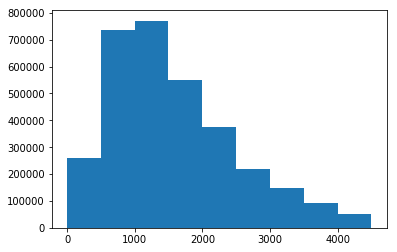

```python
bin_edges = np.arange(0, (2133+ 1.5*1247)+500, 500)
plt.hist(data = df, x ='distance', bins = bin_edges);
```

observation: most of the Destinations traveled are between 500 to 2000 meters

```python
df.distance.describe()
```

```
count    3.258378e+06
mean     1.691357e+03
std      2.837788e+04
min      0.000000e+00
25%      8.860000e+02
50%      1.402000e+03
75%      2.133000e+03
max      1.280236e+07
Name: distance, dtype: float64
```

### duration_sec histogram

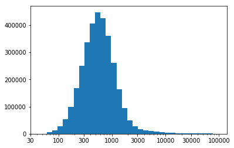

```python
bin_edges = 10 ** np.arange(1.785330, 4.936358 + 0.1, 0.1)
ticks = [30,100,300,1000,3000,10000,30000,100000]
labls = ['{}'.format(v) for v in ticks]
plt.hist(data = df, x ='duration_sec', bins = bin_edges);
plt.xscale("log");
plt.xticks(ticks,labls);
```

observation: most time spent cycling is between 300~ and 1000~ secs

```python
np.log10(df['duration_sec'].describe())
```

```
count    6.513001
mean     2.939066
std      3.384943
min      1.785330
25%      2.546543
50%      2.746634
75%      2.941014
max      4.936358
Name: duration_sec, dtype: float64
```

### member_birth_year histogram

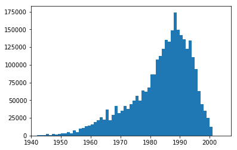

```python
bin_edges = np.arange(df['member_birth_year'].min(), df['member_birth_year'].max()+1, 1)
plt.hist(data = df, x ='member_birth_year', bins = bin_edges);
plt.xlim(1940);
```

### Discuss the distribution(s) of your variable(s) of interest. Were there any unusual points? Did you need to perform any transformations?

in the distance histogram i had to limt the x axis to q3 + 1.5 * iqr because of an outlines

### Of the features you investigated, were there any unusual distributions?

no, none of the features were there any unusual

### Did you perform any operations on the data to tidy, adjust, or change the form of the data? If so, why did you do this?

feature engined distance from the longitude and latitude coordinates in the df so i can used it to contrast between distance traveled between genders and customers types

observation: most people who cycle are in 24~ and 35~

# Bivariate Exploration

### using q3 + 1.5IQR to filter outliers

```python
q3 = df["distance"].quantile(0.75)
q1 = df["distance"].quantile(0.25)
```

```python
iqr = q3 - q1
```

```python
q3
```

```
2133.0
```

```python
q1
```

```
886.0
```

```python
iqr
```

```
1247.0
```

```python
886- 1.5*1247
```

```
-984.5
```

### Viloin graph of distance vs types of users

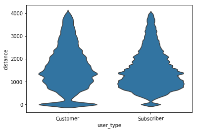

```python
sns.violinplot(data = df.query("distance <= 2133+ 1.5*1247"),x = 'user_type',y='distance',color = sns.color_palette()[0],inner=None);
plt.xticks(rotation=1);
```

observation 1: subscribers take more short trips (750 to 2000m) than customers

observation 2: customers take more long trips (2000+ m) than customers

### Viloin graph of distance vs gender

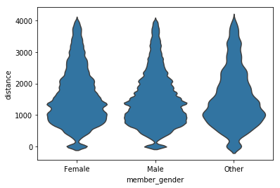

```python
sns.violinplot(data = df.query("distance <= 2133+ 1.5*1247"),x = 'member_gender',y='distance',color = sns.color_palette()[0],inner=None);
plt.xticks(rotation=1);
```

observation 1: there are more males that travel between 0 to 750~m than females but is still lesser than others

observation 2: there are more females that travel between 1250~ to 4000m than males but is still lesser than others

observation 3: others have a higer concentration of people that travel long distance

## Viloin graph of member_birth_year vs gender

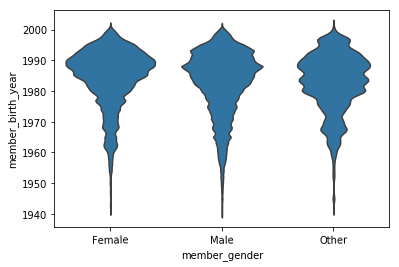

```python
sns.violinplot(data = df.query("member_birth_year >= 1940 "),x = 'member_gender',y='member_birth_year',color = sns.color_palette()[0],inner=None);
plt.xticks(rotation=1);
```

observation 1: there are more males have a higer concentration of elders (1960-1980~) than females and others

observation 2: there are more females have a higer concentration of young people (1980~-2000) than males and others

observation 3: others are either elder (1960-1970~) or in middle adulthood (1980~-1990)

### Viloin graph of member_birth_year vs types of users

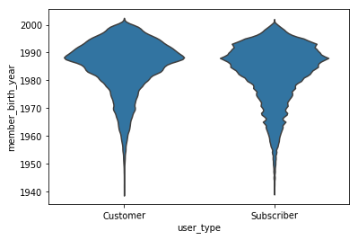

```python
sns.violinplot(data = df.query("member_birth_year >= 1940"),x = 'user_type',y='member_birth_year',color = sns.color_palette()[0],inner=None);
plt.xticks(rotation=1);
```

observation 1: they are no significant age difference between the groups

```python
df["duration_sec"].describe()
```

```
count    3.258378e+06
mean     8.690933e+02
std      2.426289e+03
min      6.100000e+01
25%      3.520000e+02
50%      5.580000e+02
75%      8.730000e+02
max      8.636900e+04
Name: duration_sec, dtype: float64
```

```python
q3 = df["duration_sec"].quantile(0.95)
q1 = df["duration_sec"].quantile(0.25)
iqr = q3 - q1
```

```python
(q3,q1,iqr)
```

```
(1827.0, 352.0, 1475.0)
```

```python
q1-1.5*iqr
```

```
-1860.5
```

```python
q3+1.5*iqr
```

```
4039.5
```

### Viloin graph of duration_sec vs gender

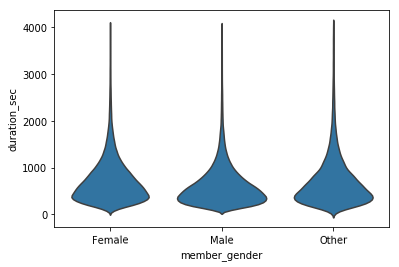

```python
sns.violinplot(data = df.query("duration_sec <= 4039.5"),x = 'member_gender',y='duration_sec',color = sns.color_palette()[0],inner=None);
plt.xticks(rotation=1);
```

observation 1: there is higer concentration males that a low travel duration (0 - 1250s) than females and others

observation 2: there is higer concentration females that a high travel duration (1250~ - 2000~s) than males but less than others

observation 3: there is higer concentration females that a very high travel duration (2000~ - 4000s) than males but less than others

### Viloin graph of duration_sec vs types of users

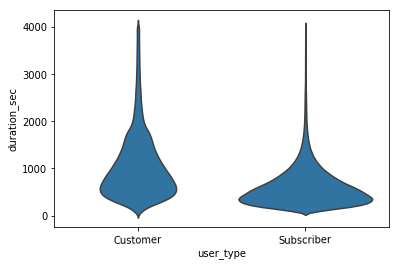

```python
sns.violinplot(data = df.query("duration_sec <= 4039.5"),x = 'user_type',y='duration_sec',color = sns.color_palette()[0],inner=None);
plt.xticks(rotation=1);
```

observation 1: there is higer concentration customers that a high travel duration (2000~s - 4000s) than subscriber

observation 2: there is higer concentration subscriber that a low travel duration (0~ - 750~s) than customers

### Heat Map of member_birth_year vs distance

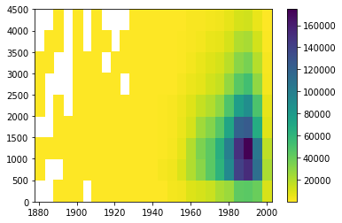

```python
xbin = np.arange(df['member_birth_year'].min(), df['member_birth_year'].max()+5, 5)
ybin = np.arange(0, (2133+ 1.5*1247)+500, 500)
plt.hist2d(data = df,x = 'member_birth_year',y='distance',cmin=0.5,cmap = 'viridis_r',bins=[xbin, ybin]);
plt.colorbar();
```

observation 1: there is high concentration young people(1980-2000) that travel the distances between 1000-1500m

### Heat Map of member_birth_year vs duration_sec

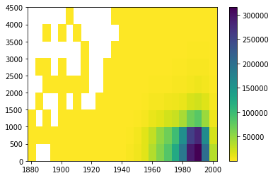

```python
xbin = np.arange(df['member_birth_year'].min(), df['member_birth_year'].max()+5, 5)
ybin = np.arange(0, 4039.5+500, 500)
plt.hist2d(data = df,x = 'member_birth_year',y='duration_sec',cmin=0.5,cmap = 'viridis_r',bins=[xbin, ybin]);
plt.colorbar();
```

observation 1: there is high concentration young people(1980-2000) that have a travel duration between 0-1250~s

### Talk about some of the relationships you observed in this part of the investigation.

look at the observation under every plot

### How did the feature(s) of interest vary with other features in the dataset?

**User Type**

- **subscribers are:**
- more likey to take short length trips
- more likey to take short duration trips
- **customers are:**
- more likey to take long length trips
- more likey to take long duration trips

- **Member Gender**
- **males are:**
- more likey to take short length trips.
- more likey to be elder
- more likey to take short duration trips
- **Female are:**
- more likey to take short length trips but short then others.
- more likey to be young
- more likey to take long duration trips
- **Others are:**
- more likey to take long length trips.
- more likey to be elder or in middle adulthood
- more likey to take very long duration trips

### Did you observe any interesting relationships between the other features (not the main feature(s) of interest)?

i did make plots but they weren't interesting

# Multivariate Exploration

```python
df.member_gender.value_counts()
```

```
Male      2256674
Female     734963
Other       50117
Name: member_gender, dtype: int64
```

### scatter of member_birth_year vs distance vs member_gender

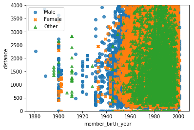

```python
xbin = np.arange(df['member_birth_year'].min(), df['member_birth_year'].max()+5, 5)
ybin = np.arange(0, (2133+ 1.5*1247)+500, 500)

cat_markers = [['Male', 'o'],
               ['Female', 'X'],
               ['Other','^']]

for cat, marker in cat_markers:
    df_temp = df.sample(300000, random_state=42)
    plot_dat = df_temp[df_temp['member_gender'] == cat]
    sns.regplot(data = plot_dat, x = 'member_birth_year', y = 'distance', marker = marker,fit_reg=False);
plt.legend(['Male','Female','Other'])
plt.ylim((0,(2133+ 1.5*1247)));
```

observation 1: not helpfull

### scatter of member_birth_year vs distance vs user_type

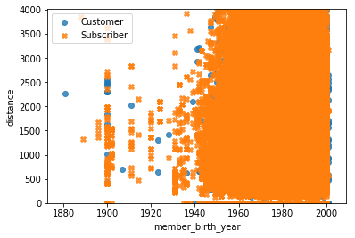

```python
xbin = np.arange(df['member_birth_year'].min(), df['member_birth_year'].max()+5, 5)
ybin = np.arange(0, (2133+ 1.5*1247)+500, 500)

cat_markers = [['Customer', 'o'],
               ['Subscriber', 'X'],]

for cat, marker in cat_markers:
    df_temp = df.sample(300000, random_state=42)
    plot_dat = df_temp[df_temp['user_type'] == cat]
    sns.regplot(data = plot_dat, x = 'member_birth_year', y = 'distance', marker = marker,fit_reg=False);
plt.legend(['Customer','Subscriber'])
plt.ylim((0,(2133+ 1.5*1247)));
```

observation 1: also not helpfull

### faceting of member_birth_year vs distance vs user_type

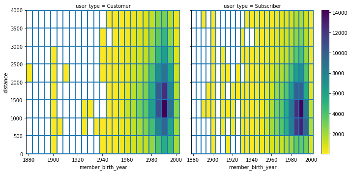

```python
xbin = np.arange(df['member_birth_year'].min(), df['member_birth_year'].max()+5, 5)
ybin = np.arange(0, (2133+ 1.5*1247)+500, 500)

df_temp = df.sample(300000, random_state=42)
g = sns.FacetGrid(data = df_temp, col = 'user_type',height=5)
g.map(plt.hist2d, 'member_birth_year','distance',cmin=0.5,cmap = 'viridis_r',bins=[xbin, ybin]);
plt.colorbar();
plt.ylim((0,(2133+ 1.5*1247)));
```

observation 1: customers usually travel from 1000 to 2000m and are between 20 - 30 year old

observation 2: Subscribers usually travel from 500 to 1500m and are between 20 - 30 year old

### faceting of member_birth_year vs distance vs member_gender

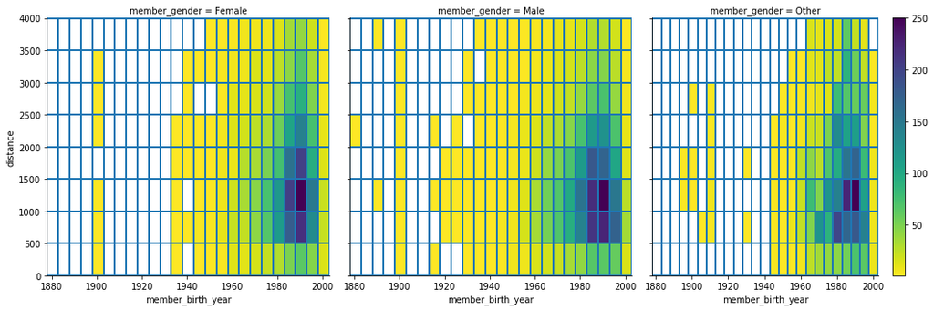

```python
xbin = np.arange(df['member_birth_year'].min(), df['member_birth_year'].max()+5, 5)
ybin = np.arange(0, (2133+ 1.5*1247)+500, 500)

df_temp = df.sample(300000, random_state=42)
g = sns.FacetGrid(data = df_temp, col = 'member_gender',height=5)
g.map(plt.hist2d, 'member_birth_year','distance',cmin=0.5,cmap = 'viridis_r',bins=[xbin, ybin]);
plt.colorbar();
plt.ylim((0,(2133+ 1.5*1247)));
```

observation 1: female usually travel from 500 to 2000m and are between 20 - 30 year old

observation 2: male usually travel from 500 to 1500m and are between 20 - 30 year old

observation 3: others usually travel from 500 to 2000m and are between 20 - 40 year old

### faceting of member_birth_year vs duration_sec vs member_gender

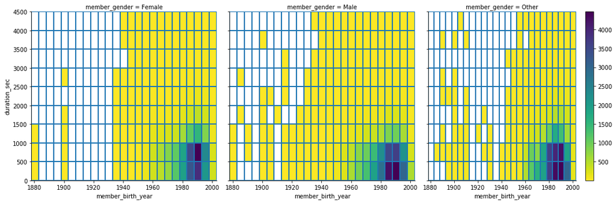

```python
xbin = np.arange(df['member_birth_year'].min(), df['member_birth_year'].max()+5, 5)
ybin = np.arange(0, 4039.5+500, 500)


g = sns.FacetGrid(data = df, col = 'member_gender',height=5)
g.map(plt.hist2d, 'member_birth_year','duration_sec',cmin=0.5,cmap = 'viridis_r',bins=[xbin, ybin]);
plt.colorbar();
```

observation 1: female usually have a duration of 0 to 1000s and are between 20 - 30 year old

observation 2: male usually have a duration of 0 to 500s and are between 20 - 30 year old

observation 3: others usually have a duration of 0 to 1000s and are between 20 - 40 year old

### faceting of member_birth_year vs duration_sec vs user_type

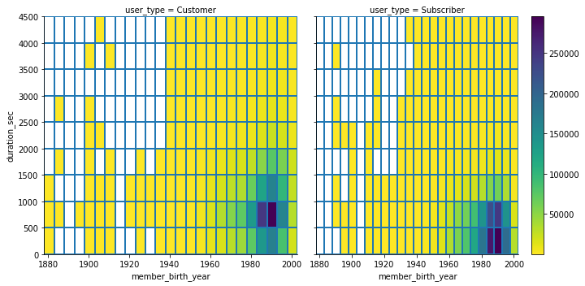

```python
xbin = np.arange(df['member_birth_year'].min(), df['member_birth_year'].max()+5, 5)
ybin = np.arange(0, 4039.5+500, 500)

g = sns.FacetGrid(data = df, col = 'user_type',height=5)
g.map(plt.hist2d, 'member_birth_year','duration_sec',cmin=0.5,cmap = 'viridis_r',bins=[xbin, ybin]);
plt.colorbar();
```

observation 1: customers usually have a duration of 500 to 1000s and are between 20 - 30 year old

observation 2: Subscribers usually have a duration of 0 to 500s and are between 20 - 30 year old

## 2-d bar chart member_gender vs user_type vs distance

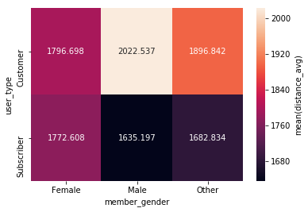

```python
cat_means = df.groupby(['member_gender', 'user_type']).mean()['distance']
cat_means = cat_means.reset_index(name = 'distance_avg')
cat_means = cat_means.pivot(index = 'user_type', columns = 'member_gender',
                            values = 'distance_avg')
sns.heatmap(cat_means, annot = True, fmt = '.3f',
           cbar_kws = {'label' : 'mean(distance_avg)'});
```

## 2-d bar chart member_gender vs user_type vs duration_sec

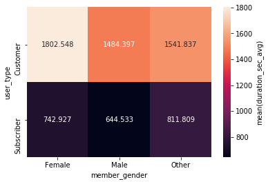

```python
cat_means = df.groupby(['member_gender', 'user_type']).mean()['duration_sec']
cat_means = cat_means.reset_index(name = 'duration_sec_avg')
cat_means = cat_means.pivot(index = 'user_type', columns = 'member_gender',
                            values = 'duration_sec_avg')
sns.heatmap(cat_means, annot = True, fmt = '.3f',
           cbar_kws = {'label' : 'mean(duration_sec_avg)'});
```

### Talk about some of the relationships you observed in this part of the investigation. Were there features that strengthened each other in terms of looking at your feature(s) of interest?

**User Type**

- **subscribers are:**
- more likey to travel from 500 to 1500m
- more likey to be between 20 - 30 year old
- more likey travel a duration of 0 to 500s
- **customers are:**
- more likey to travel from 1000 to 2000m
- more likey to be between 20 - 30 year old
- more likey to travel a duration of 500 to 1000s

- **Member Gender**
- **males are:**
- more likey to travel from 500 to 1500m
- more likey to be between 20 - 30 year old
- more likey to travel a duration of 0 to 500s
- **Female are:**
- more likey to travel from 500 to 2000m
- more likey to be between 20 - 30 year old
- more likey to travel a duration of 0 to 1000s
- **Others are:**
- more likey to travel from 500 to 2000m
- more likey to be between 20 - 40 year old
- more likey to travel a duration of 0 to 1000s

### Were there any interesting or surprising interactions between features?

```python
df.to_csv("master_data_frame.csv", sep=',', encoding='utf-8')
```